# Part II - Titanic Data Findings Presentation

by Junnuthula Yashaswini Reddy

## Investigation Overview

The objective of this presentation is to identify the key factors that influenced passenger survival on the Titanic. The analysis focuses on understanding how variables such as passenger class, gender, age, and fare are associated with survival outcomes.

### Key Insights

Most passengers traveled in Third Class. Female passengers had a higher survival rate than male passengers. First Class passengers generally paid higher fares. Higher fares were associated with higher survival rates. Passenger class, fare, and gender together provide strong insights into survival.

# Dataset Overview and Executive Summary

The Titanic dataset contains information for 891 passengers and 15 variables.

The dataset includes demographic information, passenger class, fare, embarkation details, and survival status.

This presentation highlights the most important findings discovered during exploratory data analysis using a small number of polished visualizations.

```python
import numpy as np
import pandas as pd
import matplotlib.pyplot as plt
import seaborn as sns

%matplotlib inline

sns.set_style("whitegrid")

import warnings
warnings.filterwarnings("ignore")
```

```python
df = pd.read_csv("dataset.csv")

df.head()
```

|  | survived | pclass | sex | age | sibsp | parch | fare | embarked | class | who | adult_male | deck | embark_town | alive | alone |
| --- | --- | --- | --- | --- | --- | --- | --- | --- | --- | --- | --- | --- | --- | --- | --- |
| 0 | 0 | 3 | male | 22.0 | 1 | 0 | 7.2500 | S | Third | man | True | NaN | Southampton | no | False |
| 1 | 1 | 1 | female | 38.0 | 1 | 0 | 71.2833 | C | First | woman | False | C | Cherbourg | yes | False |
| 2 | 1 | 3 | female | 26.0 | 0 | 0 | 7.9250 | S | Third | woman | False | NaN | Southampton | yes | True |
| 3 | 1 | 1 | female | 35.0 | 1 | 0 | 53.1000 | S | First | woman | False | C | Southampton | yes | False |
| 4 | 0 | 3 | male | 35.0 | 0 | 0 | 8.0500 | S | Third | man | True | NaN | Southampton | no | True |

# Visualization 1

## Passenger Age Distribution

This visualization shows the overall age distribution of Titanic passengers.

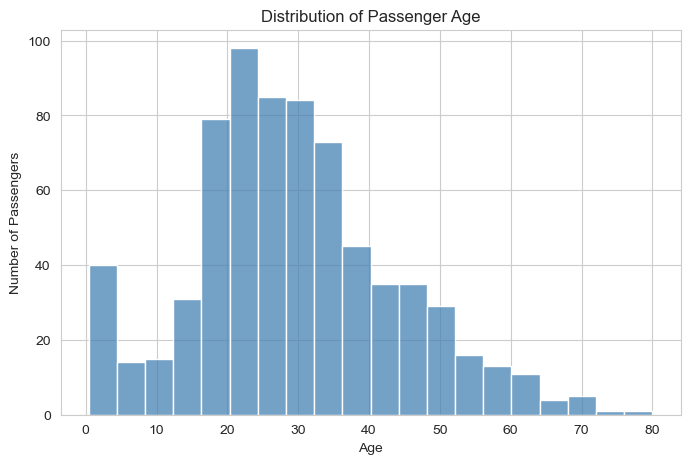

```python
plt.figure(figsize=(8,5))

sns.histplot(
    data=df,
    x="age",
    bins=20,
    color="steelblue"
)

plt.title("Distribution of Passenger Age")
plt.xlabel("Age")
plt.ylabel("Number of Passengers")

plt.show()
```

## Observation

Most passengers were between 20 and 40 years old. The distribution is slightly right-skewed, with fewer elderly passengers.

# Visualization 2

## Fare Distribution by Passenger Class

This visualization compares the fare paid by passengers in each travel class.

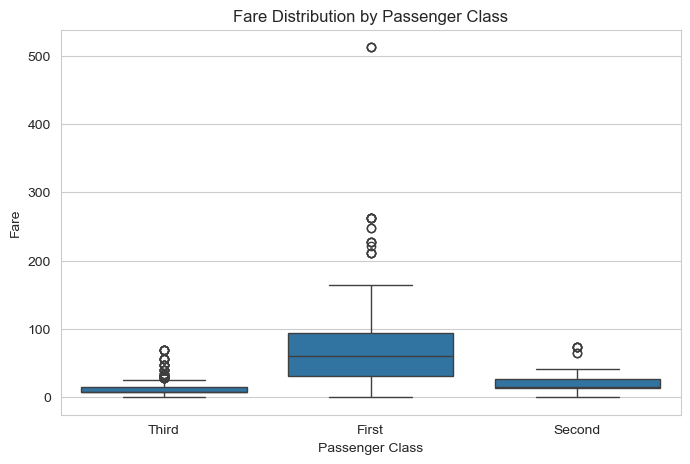

```python
plt.figure(figsize=(8,5))

sns.boxplot(
    data=df,
    x="class",
    y="fare"
)

plt.title("Fare Distribution by Passenger Class")
plt.xlabel("Passenger Class")
plt.ylabel("Fare")

plt.show()
```

## Observation

Passengers traveling in First Class generally paid significantly higher fares than passengers in Second and Third Class.

# Visualization 3

## Age vs Fare by Survival Status

This visualization explores how age and fare relate to passenger survival.

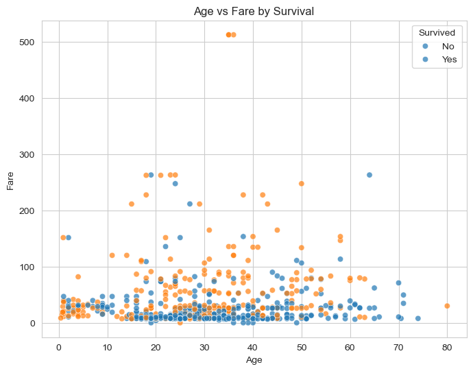

```python
plt.figure(figsize=(8,6))

sns.scatterplot(
    data=df,
    x="age",
    y="fare",
    hue="survived",
    alpha=0.7
)

plt.title("Age vs Fare by Survival")
plt.xlabel("Age")
plt.ylabel("Fare")

plt.legend(title="Survived", labels=["No", "Yes"])

plt.show()
```

### Observation

Passengers who paid higher fares were more likely to survive. Age alone does not show a strong relationship with survival.

# Final Conclusion

## Summary of Findings

Most passengers were adults between 20 and 40 years old. Third Class contained the largest number of passengers. First Class passengers generally paid the highest fares. Female passengers had higher survival rates. Higher fares were associated with higher chances of survival.

### Overall Conclusion

The analysis indicates that **passenger class, fare, and gender** were the most influential factors associated with survival on the Titanic. These findings demonstrate how exploratory data analysis can uncover meaningful insights from real-world datasets.